# Repeatable Modelling Workflow

## Graphs of ISCO predictions

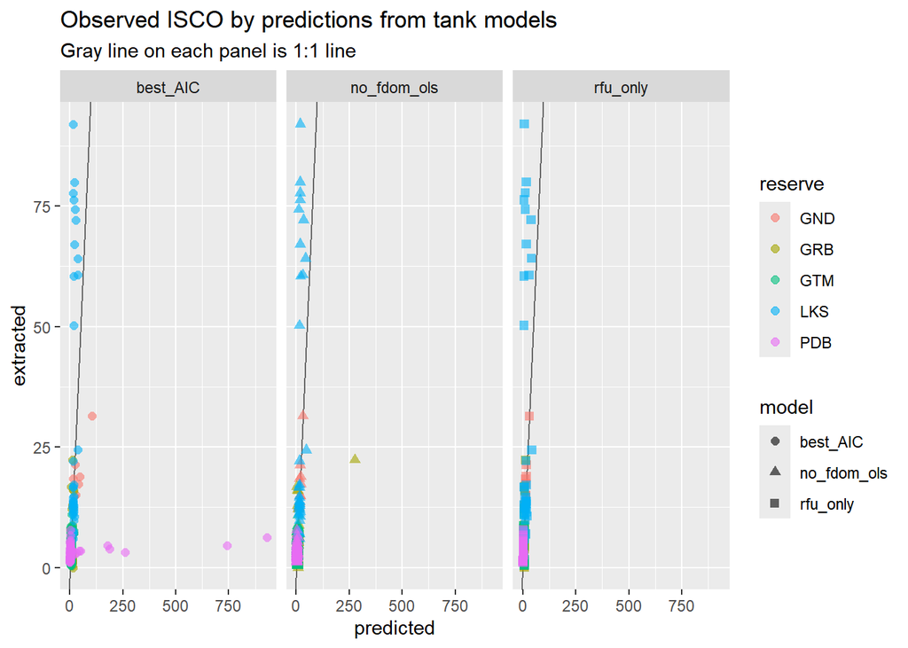

```r
ggplot(isco_preds_long) +
  geom_abline(slope = 1, intercept = 0, color = "gray40") +
  geom_point(aes(x = predicted, y = extracted, color = reserve, shape = model),
             alpha = 0.6, size = 2) +
  facet_wrap(~model) +
  labs(title = "Observed ISCO by predictions from tank models",
       subtitle = "Gray line on each panel is 1:1 line")
```

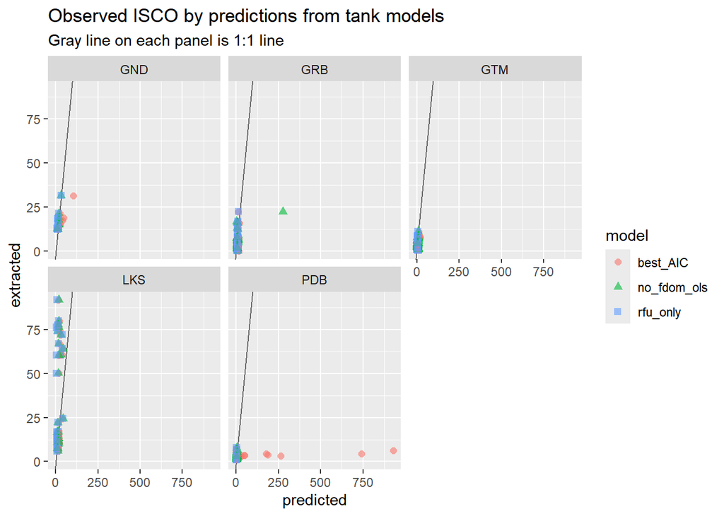

```r
ggplot(isco_preds_long) +
  geom_abline(slope = 1, intercept = 0, color = "gray40") +
  geom_point(aes(x = predicted, y = extracted, color = model, shape = model),
             alpha = 0.6, size = 2) +
  facet_wrap(~reserve) +
  labs(title = "Observed ISCO by predictions from tank models",
       subtitle = "Gray line on each panel is 1:1 line")
```

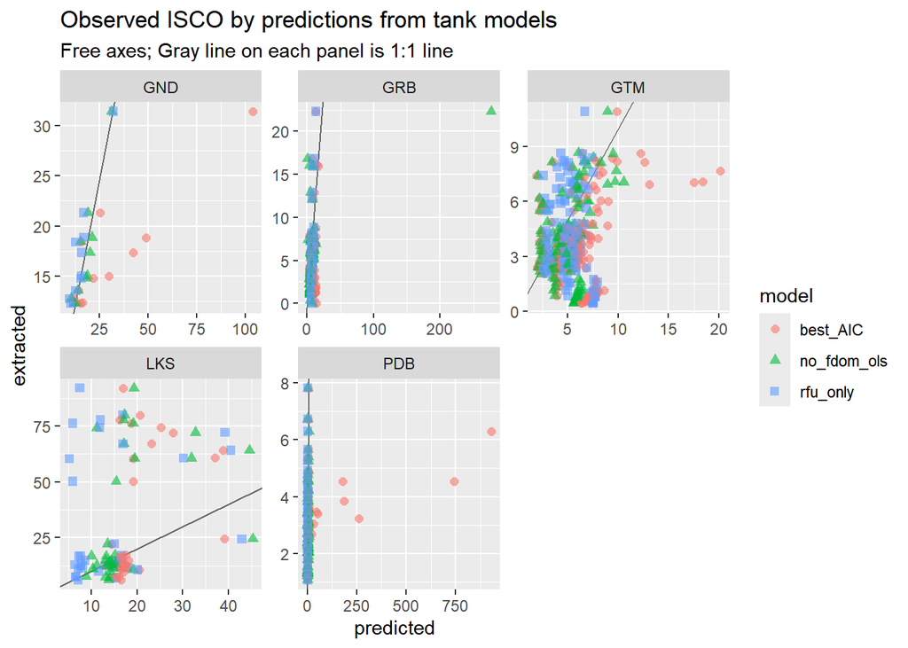

```r
ggplot(isco_preds_long) +
  geom_abline(slope = 1, intercept = 0, color = "gray40") +
  geom_point(aes(x = predicted, y = extracted, color = model, shape = model),
             alpha = 0.6, size = 2) +
  facet_wrap(~reserve, scales = "free") +
  labs(title = "Observed ISCO by predictions from tank models",
       subtitle = "Free axes; Gray line on each panel is 1:1 line")
```

# Models: Individual Reserves; ISCO Only

```r
load(here::here("data", "subset_no_NA.RData"))
table(dat$method)
```

```
##
## isco tank
##  765  311
```

```r
dat <- filter(dat, method == "isco")

# original plot settings, for later
op <- par()

# options, for MuMIn operations
# will prevent fitting sub-models to different datasets (from help file)
options(na.action = "na.fail")
```

```r
dat$response <- sqrt(dat$extracted)
```

## Modeling: Individual Reserves, ISCO (Field data) Only

**Full Model**

Includes all interactions between sensor_rfu, turbidity, and FDOM. Additionally, temp*rfu and temp*fdom. Hoping we can actually drop some of these.

**No FDOM**

If we drop FDOM and all its interactions, what do we get?

**RFU only**

This does *not* include reserve or season. If the other models above are better, reserve or season could still be the reason (vs. turbidity/temp/FDOM corrections). It would mean **local factors still have to be accounted for and modelled to get the most out of a TAL sensor**.

**RFU + season**

**Temp-Corrected RFU + season**

Temp-corrected RFU is denoted as `tc_rfu` in the model names and objects. The correction was based on a global rho value which was the average of all individual rho values, as calculated by Hannah Ramage, from the temperature interference trials. This global rho value was then inserted into the equation from Watras et al. 2017 as follows:

Temp-corrected-RFU = original-RFU / (1 + global_rho*(temp_reading - 20))

Using leave-one-out cross-validation due to low number of samples for some reserves and potential to introduce new factor levels on validation set.

```r
mod_sel_out <- list()
mod_summs_out <- list()
reserves <- unique(dat$reserve)
set.seed(1216)

for(i in seq_along(reserves)){
    res <- dat %>%
        filter(reserve == reserves[i])

    if(length(unique(res$season))>=2){
        #lots of variables
        full_ols <- glm(response ~ sensor_rfu + turb + fdom_qsu + sensor_rfu*turb*fdom_qsu + sensor_rfu*turb + sensor_rfu*fdom_qsu + turb*fdom_qsu + temp + sensor_rfu*temp + fdom_qsu*temp + season, data = res)
        # remove FDOM
        no_fdom_ols <- glm(response ~ sensor_rfu + turb +  sensor_rfu*turb + temp + sensor_rfu*temp + season, data = res)
        no_fdom_lm <- lm(response ~ sensor_rfu + turb +  sensor_rfu*turb + temp + sensor_rfu*temp + season, data = res)
        # only rfu + season
        rfu_season <- glm(response ~ sensor_rfu + season, data = res)
        rfu_season_lm <- lm(response ~ sensor_rfu + season, data = res)
        # cross-validate
        rfu_season.cv <- cv.glm(res, rfu_season, cost)
        rfu_season.df <- data.frame(model.sel(rfu_season))
        rfu_season.df$pred_test_error <- round(rfu_season.cv$delta[1], 2)
        rfu_season.df$R.2 <- round(summary(rfu_season_lm)$r.squared, 4)
        # temp-corrected rfu + season
        tc_rfu_season <- glm(response ~ rfu_temp_corrected + season, data = res)
        tc_rfu_season_lm <- lm(response ~ rfu_temp_corrected + season, data = res)
        # cross-validate
        tc_rfu_season.cv <- cv.glm(res, tc_rfu_season, cost)
        tc_rfu_season.df <- data.frame(model.sel(tc_rfu_season))
        tc_rfu_season.df$pred_test_error <- round(tc_rfu_season.cv$delta[1], 2)
        tc_rfu_season.df$R.2 <- round(summary(tc_rfu_season_lm)$r.squared, 4)

                           } else {

            full_ols <- glm(response ~ sensor_rfu + turb + fdom_qsu + sensor_rfu*turb*fdom_qsu + sensor_rfu*turb + sensor_rfu*fdom_qsu + turb*fdom_qsu + temp + sensor_rfu*temp + fdom_qsu*temp, data = res)

            no_fdom_ols <- glm(response ~ sensor_rfu + turb +  sensor_rfu*turb + temp + sensor_rfu*temp, data = res)
            no_fdom_lm <- lm(response ~ sensor_rfu + turb +  sensor_rfu*turb + temp + sensor_rfu*temp, data = res)
        }

    rfu_only <- glm(response ~ sensor_rfu, data = res)
    rfu_only_lm <- lm(response ~ sensor_rfu, data = res)

    tc_rfu_only <- glm(response ~ rfu_temp_corrected, data = res)
    tc_rfu_only_lm <- lm(response ~ rfu_temp_corrected, data = res)

    sel <- dredge(full_ols,
                  fixed = "sensor_rfu",
                  extra = c("R^2", "AdjR^2" = function(x) summary(x)$adj.r.squared))

    # perform cross-validation on top model to find median prediction error
    ols.1 <- get.models(sel, 1)[[1]]
    ols.cv <- cv.glm(res, ols.1, cost)

    no_fdom.cv <- cv.glm(res, no_fdom_ols, cost)
    no_fdom.df <- data.frame(model.sel(no_fdom_ols))
    no_fdom.df$pred_test_error <- round(no_fdom.cv$delta[1], 2)

    rfu_only.cv <- cv.glm(res, rfu_only, cost)
    rfu_only.df <- data.frame(model.sel(rfu_only))
    rfu_only.df$pred_test_error <- round(rfu_only.cv$delta[1], 2)

    tc_rfu_only.cv <- cv.glm(res, tc_rfu_only, cost)
    tc_rfu_only.df <- data.frame(model.sel(tc_rfu_only))
    tc_rfu_only.df$pred_test_error <- round(tc_rfu_only.cv$delta[1], 2)

    # pull out R^2s from lms (glms were run for cross-validation but really they're just regular linear models)
    no_fdom.df$R.2 <- round(summary(no_fdom_lm)$r.squared, 4)
    rfu_only.df$R.2 <- round(summary(rfu_only_lm)$r.squared, 4)
    tc_rfu_only.df$R.2 <- round(summary(tc_rfu_only_lm)$r.squared, 4)


    ## BIND IT ALL TOGETHER

    # only top one
    subdf <- data.frame(sel[1])
    subdf$pred_test_error <- round(ols.cv$delta[1], 2)

    # if seasonal models exist, add them to this df
    if(length(unique(res$season))>=2){
      subdf <- subdf %>%
        bind_rows(rfu_season.df, tc_rfu_season.df)
    }

    # bind other data frames of output and format
    subdf <- subdf %>%
      bind_rows(no_fdom.df, rfu_only.df, tc_rfu_only.df) %>%
      rownames_to_column(var = "model") %>%
      mutate(model = case_when(model == "...1" ~ "best_AIC",
                               TRUE ~ model)) %>%
      select(model, AICc, R.2, pred_test_error, everything()) %>%
      select(-c(delta, weight))

    # attach prediction error to it
    mod_sel_out[[i]] <- subdf

    # summary for top model
    mod_summs_out[[i]] <- summary(ols.1)


}
```

```r
mod_sel_out <- purrr::set_names(mod_sel_out, reserves)
mod_summs_out <- purrr::set_names(mod_summs_out, reserves)
```

## Summary Table

```r
mod_sel_df <- bind_rows(mod_sel_out, .id = "Reserve") %>%
  select(Reserve, model, AICc, R.2, prediction_error = pred_test_error,
         sensor_rfu, rfu_temp_corrected, fdom_qsu, turb,
         season, temp, everything()) %>%
  mutate(across(c(AICc, prediction_error), round, 2),
           across(c(R.2, sensor_rfu, rfu_temp_corrected, X.Intercept.), round, 3),
           across(c(fdom_qsu, turb, temp), round, 4),
           across(c(fdom_qsu.sensor_rfu:fdom_qsu.sensor_rfu.turb), round, 4) )


knitr::kable(mod_sel_df)
```

| Reserve | model | AICc | R.2 | prediction_error | sensor_rfu | rfu_temp_corrected | fdom_qsu | turb | season | temp | X.Intercept. | fdom_qsu.sensor_rfu | fdom_qsu.temp | fdom_qsu.turb | sensor_rfu.temp | sensor_rfu.turb | fdom_qsu.sensor_rfu.turb | df | logLik |
| --- | --- | --- | --- | --- | --- | --- | --- | --- | --- | --- | --- | --- | --- | --- | --- | --- | --- | --- | --- |
| ELK | best_AIC | 164.00 | 0.782 | 29.31 | 0.365 | NA | 0.0242 | -0.0201 | + | 0.2324 | -1.216 | -0.0120 | NA | NA | NA | NA | NA | 10 | -70.6573286 |
| ELK | rfu_season | 190.93 | 0.677 | 34.86 | 0.232 | NA | NA | NA | + | NA | 1.851 | NA | NA | NA | NA | NA | NA | 6 | -88.9749595 |
| ELK | tc_rfu_season | 189.99 | 0.681 | 34.67 | NA | 0.232 | NA | NA | + | NA | 1.868 | NA | NA | NA | NA | NA | NA | 6 | -88.5059287 |
| ELK | no_fdom_ols | 167.15 | 0.775 | 29.86 | 0.497 | NA | NA | 0.0247 | + | 0.2605 | -1.448 | NA | NA | NA | -0.0105 | -0.0166 | NA | 10 | -72.2324976 |
| ELK | rfu_only | 219.10 | 0.531 | 39.18 | 0.410 | NA | NA | NA | NA | NA | 2.161 | NA | NA | NA | NA | NA | NA | 3 | -106.4168089 |
| ELK | tc_rfu_only | 217.58 | 0.538 | 38.90 | NA | 0.403 | NA | NA | NA | NA | 2.185 | NA | NA | NA | NA | NA | NA | 3 | -105.6544111 |
| GND | best_AIC | -769.96 | 1.000 | 71.96 | 38.775 | NA | 1.5298 | 9.8675 | NA | -2.0731 | -103.060 | -0.5831 | 0.0059 | -0.1023 | 0.6451 | -3.3368 | 0.0345 | 12 | 318.9789369 |
| GND | no_fdom_ols | 47.60 | 0.883 | 35.93 | 6.153 | NA | NA | -0.1992 | NA | 0.7649 | -18.084 | NA | NA | NA | -0.2069 | 0.0614 | NA | 7 | 1.8648166 |
| GND | rfu_only | 8.47 | 0.849 | 10.75 | 1.294 | NA | NA | NA | NA | NA | 0.407 | NA | NA | NA | NA | NA | NA | 3 | 0.4794877 |
| GND | tc_rfu_only | 7.60 | 0.860 | 11.06 | NA | 1.173 | NA | NA | NA | NA | 0.362 | NA | NA | NA | NA | NA | NA | 3 | 0.9154655 |
| GTM | best_AIC | 52.24 | 0.805 | 25.96 | -0.104 | NA | 0.0084 | NA | + | -0.2157 | 4.007 | -0.0103 | 0.0005 | NA | 0.0623 | NA | NA | 11 | -14.1217051 |
| GTM | rfu_season | 132.98 | 0.631 | 32.35 | -0.249 | NA | NA | NA | + | NA | 2.168 | NA | NA | NA | NA | NA | NA | 6 | -60.1832765 |
| GTM | tc_rfu_season | 139.98 | 0.612 | 33.34 | NA | -0.232 | NA | NA | + | NA | 2.100 | NA | NA | NA | NA | NA | NA | 6 | -63.6838861 |
| GTM | no_fdom_ols | 82.28 | 0.756 | 27.38 | -1.137 | NA | NA | 0.0105 | + | -0.0776 | 3.672 | NA | NA | NA | 0.0458 | 0.0011 | NA | 10 | -30.3113847 |
| GTM | rfu_only | 252.45 | 0.114 | 51.09 | -0.205 | NA | NA | NA | NA | NA | 2.453 | NA | NA | NA | NA | NA | NA | 3 | -123.1394769 |
| GTM | tc_rfu_only | 266.40 | 0.024 | 52.88 | NA | -0.088 | NA | NA | NA | NA | 2.125 | NA | NA | NA | NA | NA | NA | 3 | -130.1137226 |
| LKS | best_AIC | 118.31 | 0.902 | 22.94 | 1.014 | NA | -0.1746 | 0.0857 | + | 0.8106 | 41.265 | NA | -0.0098 | NA | NA | -0.1444 | NA | 10 | -46.1843676 |
| LKS | rfu_season | 199.84 | 0.277 | 51.67 | 0.374 | NA | NA | NA | + | NA | 2.505 | NA | NA | NA | NA | NA | NA | 5 | -94.2063224 |
| LKS | tc_rfu_season | 199.86 | 0.277 | 51.59 | NA | 0.367 | NA | NA | + | NA | 2.630 | NA | NA | NA | NA | NA | NA | 5 | -94.2135663 |
| LKS | no_fdom_ols | 186.81 | 0.565 | 46.16 | 0.969 | NA | NA | -0.1277 | + | -1.4605 | 19.923 | NA | NA | NA | 0.0214 | -0.1165 | NA | 9 | -82.0345229 |
| LKS | rfu_only | 208.86 | 0.034 | 65.85 | 0.221 | NA | NA | NA | NA | NA | 4.641 | NA | NA | NA | NA | NA | NA | 3 | -101.1573276 |
| LKS | tc_rfu_only | 208.00 | 0.051 | 65.41 | NA | 0.271 | NA | NA | NA | NA | 4.536 | NA | NA | NA | NA | NA | NA | 3 | -100.7270959 |
| NIW_isco | best_AIC | 71.22 | 0.866 | 16.52 | 4.453 | NA | 0.0240 | 0.0137 | NA | 0.1247 | -4.938 | NA | NA | NA | -0.1174 | NA | NA | 7 | -27.7355066 |
| NIW_isco | no_fdom_ols | 96.52 | 0.810 | 19.76 | 3.762 | NA | NA | 0.0106 | NA | 0.0976 | -1.924 | NA | NA | NA | -0.0979 | 0.0034 | NA | 7 | -40.3867257 |
| NIW_isco | rfu_only | 102.31 | 0.766 | 20.54 | 0.922 | NA | NA | NA | NA | NA | 1.313 | NA | NA | NA | NA | NA | NA | 3 | -47.9801466 |
| NIW_isco | tc_rfu_only | 104.70 | 0.758 | 20.84 | NA | 0.809 | NA | NA | NA | NA | 1.357 | NA | NA | NA | NA | NA | NA | 3 | -49.1740802 |
| OWC | best_AIC | 287.83 | 0.862 | 26.37 | 0.265 | NA | 0.0058 | -0.0078 | + | 0.1618 | 1.433 | -0.0050 | 0.0014 | NA | NA | 0.0047 | NA | 12 | -130.5809124 |
| OWC | rfu_season | 397.93 | 0.642 | 42.41 | 0.216 | NA | NA | NA | + | NA | 1.741 | NA | NA | NA | NA | NA | NA | 6 | -192.6221919 |
| OWC | tc_rfu_season | 397.98 | 0.641 | 42.50 | NA | 0.225 | NA | NA | + | NA | 1.770 | NA | NA | NA | NA | NA | NA | 6 | -192.6479967 |
| OWC | no_fdom_ols | 295.83 | 0.848 | 24.83 | 0.088 | NA | NA | -0.0051 | + | 0.2449 | 1.556 | NA | NA | NA | -0.0042 | 0.0038 | NA | 10 | -136.9895356 |
| OWC | rfu_only | 437.02 | 0.491 | 54.08 | 0.296 | NA | NA | NA | NA | NA | 2.731 | NA | NA | NA | NA | NA | NA | 3 | -215.4171941 |
| OWC | tc_rfu_only | 436.37 | 0.494 | 53.77 | NA | 0.289 | NA | NA | NA | NA | 2.765 | NA | NA | NA | NA | NA | NA | 3 | -215.0898159 |
| PDB | best_AIC | -7.43 | 0.765 | 18.27 | 1.968 | NA | 0.0517 | 0.1150 | + | 0.0740 | -0.421 | NA | NA | -0.0070 | -0.1107 | NA | NA | 10 | 15.6122130 |
| PDB | rfu_season | 30.26 | 0.510 | 25.99 | 0.760 | NA | NA | NA | + | NA | 1.099 | NA | NA | NA | NA | NA | NA | 5 | -9.6529557 |
| PDB | tc_rfu_season | 33.02 | 0.491 | 26.80 | NA | 0.783 | NA | NA | + | NA | 1.150 | NA | NA | NA | NA | NA | NA | 5 | -11.0334049 |
| PDB | no_fdom_ols | -4.34 | 0.744 | 18.54 | 1.613 | NA | NA | 0.1046 | + | 0.0734 | 0.074 | NA | NA | NA | -0.0746 | -0.0714 | NA | 9 | 12.6934041 |
| PDB | rfu_only | 59.30 | 0.203 | 34.22 | 0.636 | NA | NA | NA | NA | NA | 1.245 | NA | NA | NA | NA | NA | NA | 3 | -26.4678165 |
| PDB | tc_rfu_only | 61.04 | 0.183 | 34.96 | NA | 0.619 | NA | NA | NA | NA | 1.293 | NA | NA | NA | NA | NA | NA | 3 | -27.3361788 |
| WEL | best_AIC | 307.19 | 0.420 | 109.97 | 0.223 | NA | -0.0665 | NA | NA | 0.1409 | 0.198 | NA | 0.0051 | NA | NA | NA | NA | 6 | -146.9797644 |
| WEL | rfu_season | 327.10 | 0.219 | 88.70 | 0.397 | NA | NA | NA | + | NA | 0.541 | NA | NA | NA | NA | NA | NA | 5 | -158.1165781 |
| WEL | tc_rfu_season | 326.77 | 0.222 | 87.91 | NA | 0.563 | NA | NA | + | NA | 0.521 | NA | NA | NA | NA | NA | NA | 5 | -157.9507389 |
| WEL | no_fdom_ols | 312.19 | 0.439 | 115.92 | 3.126 | NA | NA | 0.0057 | + | 0.4603 | -2.051 | NA | NA | NA | -0.2025 | -0.0797 | NA | 9 | -145.7123905 |
| WEL | rfu_only | 340.46 | 0.009 | 116.06 | 0.472 | NA | NA | NA | NA | NA | 1.889 | NA | NA | NA | NA | NA | NA | 3 | -167.0627386 |
| WEL | tc_rfu_only | 339.43 | 0.022 | 114.61 | NA | 0.835 | NA | NA | NA | NA | 1.709 | NA | NA | NA | NA | NA | NA | 3 | -166.5451883 |
| GRB | best_AIC | 44.38 | 0.875 | 22.48 | 0.429 | NA | -0.0015 | 0.0187 | + | 0.0578 | 0.591 | -0.0058 | NA | -0.0013 | NA | -0.0026 | 0.0009 | 12 | -8.7694706 |
| GRB | rfu_season | 191.50 | 0.528 | 40.51 | 0.854 | NA | NA | NA | + | NA | 0.915 | NA | NA | NA | NA | NA | NA | 5 | -90.4952537 |
| GRB | tc_rfu_season | 186.98 | 0.545 | 40.36 | NA | 0.840 | NA | NA | + | NA | 0.934 | NA | NA | NA | NA | NA | NA | 5 | -88.2320449 |
| GRB | no_fdom_ols | 127.03 | 0.741 | 29.40 | -1.591 | NA | NA | 0.0611 | + | -0.2030 | 4.763 | NA | NA | NA | 0.1051 | -0.0122 | NA | 9 | -53.7179738 |
| GRB | rfu_only | 196.11 | 0.493 | 44.05 | 0.844 | NA | NA | NA | NA | NA | 0.630 | NA | NA | NA | NA | NA | NA | 3 | -94.9543739 |
| GRB | tc_rfu_only | 192.00 | 0.509 | 43.68 | NA | 0.821 | NA | NA | NA | NA | 0.631 | NA | NA | NA | NA | NA | NA | 3 | -92.9006088 |

```r
write.csv(mod_sel_df, file = here::here("model_coeffs",                                     "IndRes_ISCOOnly.csv"), row.names = FALSE)
```

# Graph of model diagnostics by reserve

```r
diags <- mod_sel_df %>%
  select(Reserve, model, AICc, R.2, prediction_error) %>%
  pivot_longer(-c(Reserve, model), names_to = "diagnostic", values_to = "value") %>%
  mutate(diagnostic = case_when(diagnostic == "R.2" ~ "R^2",
                                diagnostic == "prediction_error" ~ "Prediction Error",
                                TRUE ~ diagnostic),
         model_type = case_when(stringr::str_starts(model, "rfu") ~ "RFU",
                                stringr::str_starts(model, "tc_rfu") ~ "TC-RFU",
                                TRUE ~ "multi-vars"))
```

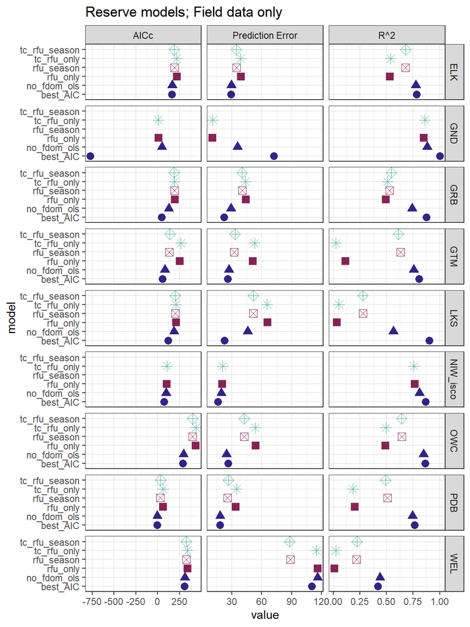

```r
my_shapes <- c(16, 17, 15, 7, 8, 9)

# colors below are from khroma::muted and are colorblind-friendly
# though that's not really necessary here because we also have shapes and names

ggplot(diags, aes(x = value, y = model)) +
  geom_point(size = 3, aes(color = model_type, shape = model)) +
  facet_grid(Reserve~diagnostic, scales = "free_x") +
  scale_shape_manual(values = rep(my_shapes, 2)) +
  scale_color_manual(values = c("#332288", "#882255", "#44AA99")) +
  theme_bw() +
  theme(legend.position = "none") +
  ggtitle("Reserve models; Field data only")
```

Get rid of GND and PDB due to that massive overfitting that messes up the AICc scale, and also HEE_w2 because it was such a small sample size.

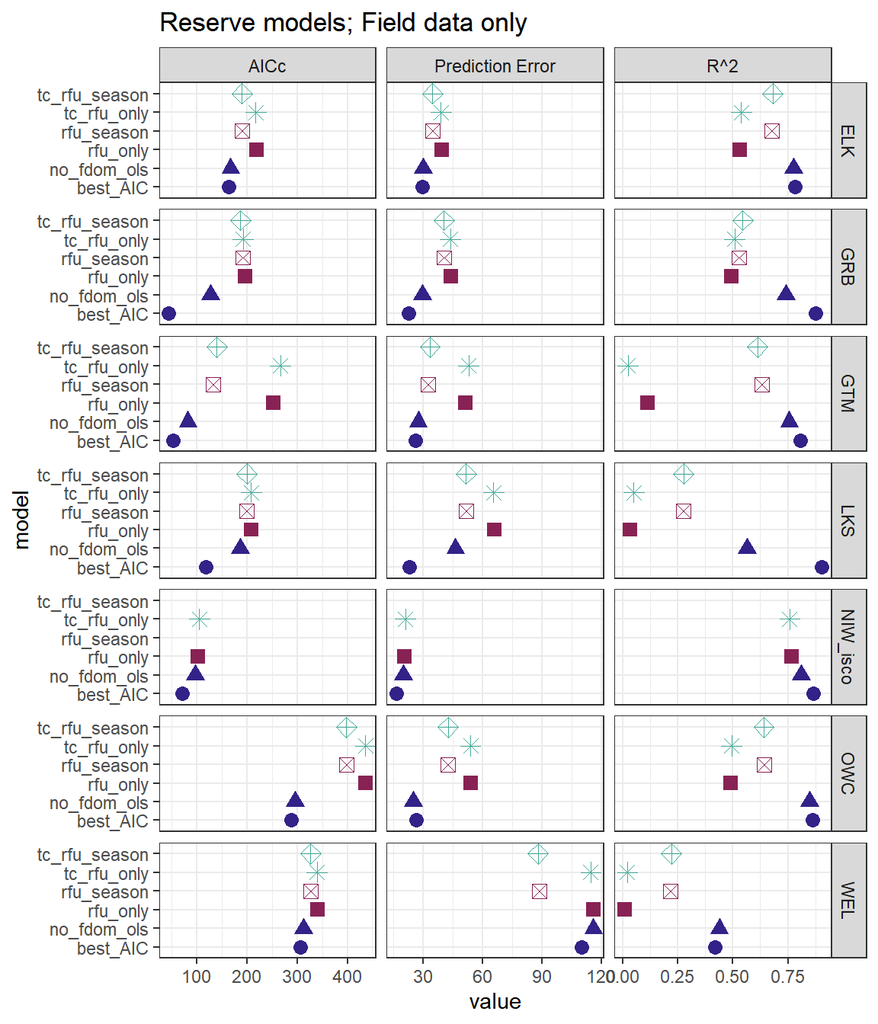

```r
diags %>%
  filter(!(Reserve %in% c("GND", "PDB", "HEE_w2"))) %>%
ggplot(aes(x = value, y = model)) +
  geom_point(size = 3, aes(color = model_type, shape = model)) +
  facet_grid(Reserve~diagnostic, scales = "free_x") +
  scale_shape_manual(values = rep(my_shapes, 2)) +
  scale_color_manual(values = c("#332288", "#882255", "#44AA99")) +
  theme_bw() +
  theme(legend.position = "none") +
  ggtitle("Reserve models; Field data only")
```

Same thing, but also get rid of temp-corrected RFU because it adds clutter.

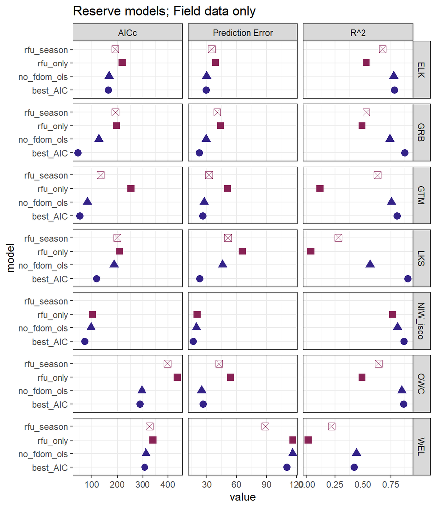

```r
diags %>%
  filter(!(Reserve %in% c("GND", "PDB", "HEE_w2")),
         !(model %in% c("tc_rfu_season", "tc_rfu_only"))) %>%
ggplot(aes(x = value, y = model)) +
  geom_point(size = 3, aes(color = model_type, shape = model)) +
  facet_grid(Reserve~diagnostic, scales = "free_x") +
  scale_shape_manual(values = rep(my_shapes, 2)) +
  scale_color_manual(values = c("#332288", "#882255", "#44AA99")) +
  theme_bw() +
  theme(legend.position = "none") +
  ggtitle("Reserve models; Field data only")
```

```r
ggsave(here::here("model_figures",
                  "IndRes_FieldOnly_4Mods_diagnostics.png"),
       width = 6, height = 7, units = "in")
```

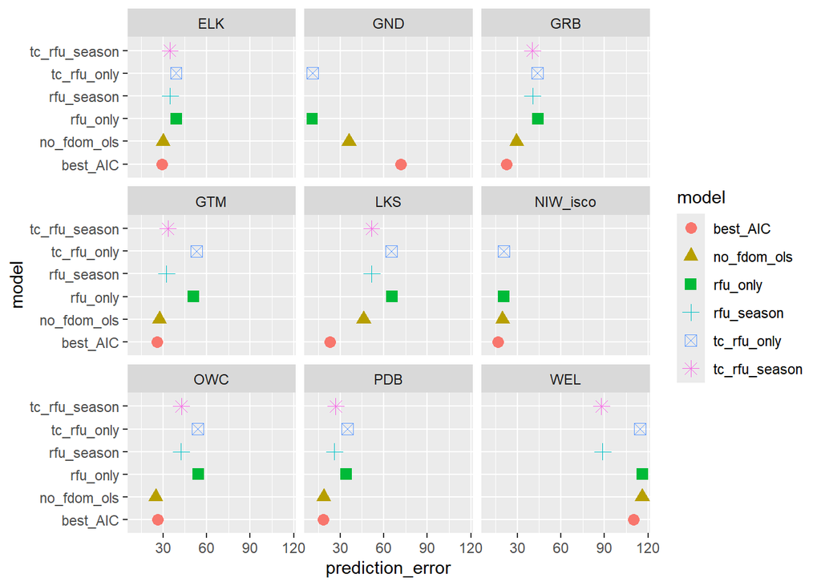

```r
ggplot(mod_sel_df, aes(x = prediction_error, y = model,
                       color = model, shape = model)) +
  geom_point(size = 3) +
  facet_wrap(~Reserve)
```

# Graphic: R^2 and prediction error for all models

Reserve code ‘ALL’ represents the combined-reserve models.

```r
files_allRes <- c("AllRes_TankAndISCO", "AllRes_TankOnly")
files_indRes <- c("IndRes_TankAndISCO", "IndRes_TankOnly")
```

```r
# read in Individual Reserve data frames
dat_ind_ti <- read_csv(here::here("model_coeffs",
                           paste0(files_indRes[[1]], ".csv")))

dat_ind_t <- read_csv(here::here("model_coeffs",
                           paste0(files_indRes[[2]], ".csv")))

# combine for faceting
dat_ind_t$data_source <- "Tank Only"
dat_ind_ti$data_source <- "Tank + ISCO"

dat_all <- bind_rows(dat_ind_t, dat_ind_ti)
```

```r
# all reserves
all_ti <- read_csv(here::here("model_coeffs",
                           paste0(files_allRes[[1]], ".csv")))

all_t <- read_csv(here::here("model_coeffs",
                           paste0(files_allRes[[2]], ".csv")))
```

```r
all_t <- all_t %>%
  mutate(data_source = "Tank Only",
         Reserve = 'ALL')

all_ti <- all_ti %>%
  mutate(data_source = "Tank + ISCO",
         Reserve = 'ALL')

dat_all <- bind_rows(dat_all, all_t, all_ti)
```

```r
# main 3 models: best_AIC, no_fdom_ols, rfu_only
dat_main3 <- dat_all %>%
  filter(model %in% c("best_AIC", "no_fdom_ols", "rfu_only"))

# other potential biggies: rfu_season, rfu_reserve
dat_main5 <- dat_all %>%
  filter(model %in% c("best_AIC", "no_fdom_ols", "rfu_only",
                      "rfu_season", "rfu_reserve"))
```

# Main 3 models

Original diagnostic plot

```r
rsq <- ggplot(dat_main3,
       aes(x = Reserve,
           y = R.2,
           color = model,
           shape = model)) +
  geom_point(size = 3,
             alpha = 0.7) +
  facet_wrap(~data_source) +
  theme_bw() +
  theme(axis.text.x = element_text(angle = 45, hjust = 1),
        strip.text = element_blank()) +
  labs(x = NULL, y = expression("R"^"2"))

err <- ggplot(dat_main3,
       aes(x = Reserve,
           y = prediction_error,
           color = model,
           shape = model)) +
  geom_point(size = 3,
             alpha = 0.7) +
  facet_wrap(~data_source) +
  theme_bw() +
  theme(axis.text.x = element_text(angle = 45, hjust = 1),
        strip.text = element_blank()) +
  labs(x = NULL, y = "Median Absolute \nPrediction Error")
```

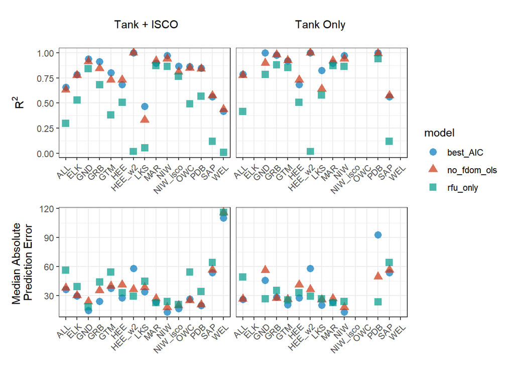

```r
# try adding labels with some code from the stackoverflow answer
# https://stackoverflow.com/a/60354844
col1 <- ggplot() + annotate(geom = 'text', x=1, y=1, label="Tank + ISCO") + theme_void()

col2 <- ggplot() + annotate(geom = 'text', x=1, y=1, label="Tank Only") + theme_void()


# from khroma::vibrant
colors <- scale_color_manual(values = rep(c("#0077BB", "#CC3311", "#009988"), 4))

(col1 + col2) / (rsq + colors) / (err + colors) +
  plot_layout(guides = 'collect',
              heights = c(1, 3, 3))
```

```r
ggsave(here::here("model_figures", "diagnostic_plot_main3models.png"),
       width = 8.5, height = 6.5, units = "in")
```

# Main 3 + rfu and season/reserve only

How much of a difference does it make if we only add one of the factors to rfu? If not much difference from rfu-only, then it is the other sensor readings that matter.

```r
rsq <- ggplot(dat_main5,
       aes(x = Reserve,
           y = R.2,
           color = model,
           shape = model)) +
  geom_point(size = 3,
             alpha = 0.7) +
  facet_wrap(~data_source) +
  theme_bw() +
  theme(axis.text.x = element_text(angle = 45, hjust = 1),
        strip.text = element_blank()) +
  # scale_shape_manual(values = 1:15) +
  labs(x = NULL, y = expression("R"^"2"))

err <- ggplot(dat_main5,
       aes(x = Reserve,
           y = prediction_error,
           color = model,
           shape = model)) +
  geom_point(size = 3,
             alpha = 0.7) +
  facet_wrap(~data_source) +
  theme_bw() +
  theme(axis.text.x = element_text(angle = 45, hjust = 1),
        strip.text = element_blank()) +
  # scale_shape_manual(values = 1:15) +
  labs(x = NULL, y = "Median Absolute \nPrediction Error")
```

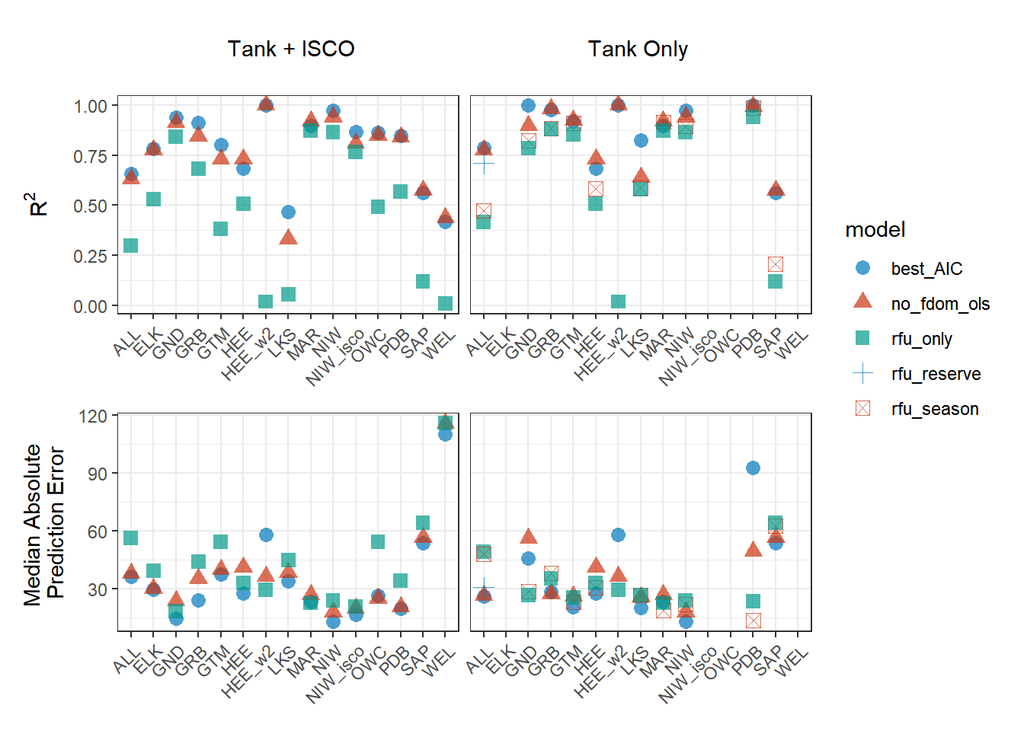

```r
# try adding labels with some code from the stackoverflow answer
# https://stackoverflow.com/a/60354844
col1 <- ggplot() + annotate(geom = 'text', x=1, y=1, label="Tank + ISCO") + theme_void()

col2 <- ggplot() + annotate(geom = 'text', x=1, y=1, label="Tank Only") + theme_void()


# from khroma::vibrant
colors <- scale_color_manual(values = rep(c("#0077BB", "#CC3311", "#009988"), 4))

(col1 + col2) / (rsq + colors) / (err + colors) +
  plot_layout(guides = 'collect',
              heights = c(1, 3, 3))
```

```r
ggsave(here::here("model_figures", "diagnostic_plot_main3-plus2.png"),
       width = 8.5, height = 6.5, units = "in")
```

# Lots of models

Includes temperature-corrected rfu, from interference tests!

```r
rsq <- ggplot(dat_all,
       aes(x = Reserve,
           y = R.2,
           color = model,
           shape = model)) +
  geom_point(size = 3,
             alpha = 0.8) +
  facet_wrap(~data_source) +
  theme_bw() +
  theme(axis.text.x = element_text(angle = 45, hjust = 1),
        strip.text = element_blank()) +
  scale_shape_manual(values = 1:15) +
  labs(x = NULL, y = expression("R"^"2"))

err <- ggplot(dat_all,
       aes(x = Reserve,
           y = prediction_error,
           color = model,
           shape = model)) +
  geom_point(size = 3,
             alpha = 0.8) +
  facet_wrap(~data_source) +
  theme_bw() +
  theme(axis.text.x = element_text(angle = 45, hjust = 1),
        strip.text = element_blank()) +
  scale_shape_manual(values = 1:15) +
  labs(x = NULL, y = "Median Absolute \nPrediction Error")
```

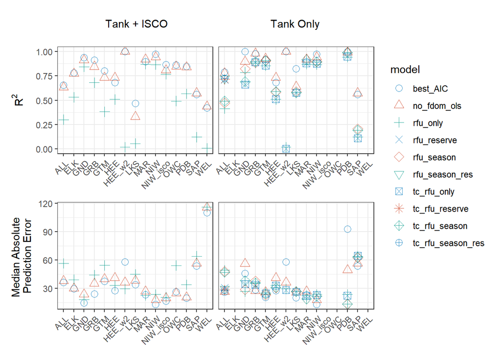

```r
# try adding labels with some code from the stackoverflow answer
# https://stackoverflow.com/a/60354844
col1 <- ggplot() + annotate(geom = 'text', x=1, y=1, label="Tank + ISCO") + theme_void()

col2 <- ggplot() + annotate(geom = 'text', x=1, y=1, label="Tank Only") + theme_void()


# from khroma::vibrant
colors <- scale_color_manual(values = rep(c("#0077BB", "#CC3311", "#009988"), 4))

(col1 + col2) / (rsq + colors) / (err + colors) +
  plot_layout(guides = 'collect',
              heights = c(1, 3, 3))
```

```r
ggsave(here::here("model_figures", "diagnostic_plot_updated_lotsamodels.png"),
       width = 8.5, height = 6.5, units = "in")
```